# ML

## Airlines review : customers satisfaction

## Project presentation

This project applies supervised machine learning techniques to a airline dataset in order to predict passenger satisfaction regarding different airlines and traveling.

The data contains structured numerical and categorical variables describing different aspects of flight experience. The dataset contains 23 variables (such as seat comfort, onboard service, food quality, delays etc.) and more than 130,000 observations. It is already splitted into two different sets:

- A train dataset with 104,000 observations (80%)
- A test dataset with 26,000 observations (20%)

The objective is to understand how these factors influence overall passenger satisfaction and to build a classification model that can predict whether a passenger is satisfied or not regarding its flight experience.

The target variable will then be passenger satisfaction, a binary outcome indicating whether a passenger is satisfied or dissatisfied.

All other variables are used as independant variables (features) to explain and predict this outcome. Since the task involves a binary target variable, the problem will be formulated as a supervised classification machine learning problem.

## Plan of the notebook :

First, an exploratory data analysis is conducted to better understand the dataset, explore variable distributions, and identify potential relationships between the features and the target variable.

Next, the data is preprocessed, including encoding of categorical variables, feature scaling where necessary, and a train test split (which is already done with the imported dataset, 80/20%).

Finally, classification models will be trained and evaluated. A random forest model will be applied to capture complex relationships. We will then compute the model's performance using standard evaluation metrics such as the confusion matrix, accuracy, and ROC AUC, before drawing final conclusions.

## Data and libraries importation

```python
import pandas as pd
import matplotlib.pyplot as plt
import numpy as np
import seaborn as sns

from sklearn.model_selection import train_test_split, KFold
from sklearn.metrics import mean_squared_error, mean_absolute_error
from sklearn.linear_model import LinearRegression
from sklearn.ensemble import RandomForestClassifier
```

```python
import kagglehub

# Download latest version
path = kagglehub.dataset_download("teejmahal20/airline-passenger-satisfaction")

print("Path to dataset files:", path)
```

```
Path to dataset files: /home/codespace/.cache/kagglehub/datasets/teejmahal20/airline-passenger-satisfaction/versions/1
```

```python
import os

path = path
os.listdir(path)
```

```
['train.csv', 'test.csv']
```

```python
train_df = pd.read_csv(os.path.join(path, 'train.csv'))
test_df  = pd.read_csv(os.path.join(path, 'test.csv'))
```

```python
train_df.info()
test_df.info()
```

```
<class 'pandas.core.frame.DataFrame'>
RangeIndex: 103904 entries, 0 to 103903
Data columns (total 25 columns):
 #   Column                             Non-Null Count   Dtype
---  ------                             --------------   -----
 0   Unnamed: 0                         103904 non-null  int64
 1   id                                 103904 non-null  int64
 2   Gender                             103904 non-null  object
 3   Customer Type                      103904 non-null  object
 4   Age                                103904 non-null  int64
 5   Type of Travel                     103904 non-null  object
 6   Class                              103904 non-null  object
 7   Flight Distance                    103904 non-null  int64
 8   Inflight wifi service              103904 non-null  int64
 9   Departure/Arrival time convenient  103904 non-null  int64
```

[output cut: 49 more lines]

## Exploratory Data Analysis (EDA) and data cleaning

```python
train_df.head()
```

|  | Unnamed: 0 | id | Gender | Customer Type | Age | Type of Travel | Class | Flight Distance | Inflight wifi service | Departure/Arrival time convenient | ... | Inflight entertainment | On-board service | Leg room service | Baggage handling | Checkin service | Inflight service | Cleanliness | Departure Delay in Minutes | Arrival Delay in Minutes | satisfaction |
| --- | --- | --- | --- | --- | --- | --- | --- | --- | --- | --- | --- | --- | --- | --- | --- | --- | --- | --- | --- | --- | --- |
| 0 | 0 | 70172 | Male | Loyal Customer | 13 | Personal Travel | Eco Plus | 460 | 3 | 4 | ... | 5 | 4 | 3 | 4 | 4 | 5 | 5 | 25 | 18.0 | neutral or dissatisfied |
| 1 | 1 | 5047 | Male | disloyal Customer | 25 | Business travel | Business | 235 | 3 | 2 | ... | 1 | 1 | 5 | 3 | 1 | 4 | 1 | 1 | 6.0 | neutral or dissatisfied |
| 2 | 2 | 110028 | Female | Loyal Customer | 26 | Business travel | Business | 1142 | 2 | 2 | ... | 5 | 4 | 3 | 4 | 4 | 4 | 5 | 0 | 0.0 | satisfied |
| 3 | 3 | 24026 | Female | Loyal Customer | 25 | Business travel | Business | 562 | 2 | 5 | ... | 2 | 2 | 5 | 3 | 1 | 4 | 2 | 11 | 9.0 | neutral or dissatisfied |
| 4 | 4 | 119299 | Male | Loyal Customer | 61 | Business travel | Business | 214 | 3 | 3 | ... | 3 | 3 | 4 | 4 | 3 | 3 | 3 | 0 | 0.0 | satisfied |

5 rows × 25 columns

### Missing values check

```python
print(train_df.isnull().sum())
print(test_df.isnull().sum())
train_df.dropna(inplace=True)
test_df.dropna(inplace=True)
```

```
Unnamed: 0                             0
id                                     0
Gender                                 0
Customer Type                          0
Age                                    0
Type of Travel                         0
Class                                  0
Flight Distance                        0
Inflight wifi service                  0
Departure/Arrival time convenient      0
Ease of Online booking                 0
Gate location                          0
Food and drink                         0
Online boarding                        0
Seat comfort                           0
Inflight entertainment                 0
On-board service                       0
Leg room service                       0
Baggage handling                       0
Checkin service                        0
Inflight service                       0
Cleanliness                            0
Departure Delay in Minutes             0
Arrival Delay in Minutes             310
satisfaction                           0
dtype: int64
Unnamed: 0                            0
id                                    0
Gender                                0
Customer Type                         0
Age                                   0
Type of Travel                        0
Class                                 0
Flight Distance                       0
Inflight wifi service                 0
Departure/Arrival time convenient     0
Ease of Online booking                0
Gate location                         0
Food and drink                        0
Online boarding                       0
Seat comfort                          0
Inflight entertainment                0
On-board service                      0
Leg room service                      0
Baggage handling                      0
Checkin service                       0
Inflight service                      0
Cleanliness                           0
Departure Delay in Minutes            0
Arrival Delay in Minutes             83
satisfaction                          0
dtype: int64
```

```python
train_df.isnull().sum()
test_df.isnull().sum()
train_df.dropna(inplace=True)
test_df.dropna(inplace=True)
```

### Duplicates check

```python
print(train_df.duplicated().sum())
print(test_df.duplicated().sum())
```

```
0
0
```

No duplicates found here

```python
train_df.describe()
```

|  | Unnamed: 0 | id | Age | Flight Distance | Inflight wifi service | Departure/Arrival time convenient | Ease of Online booking | Gate location | Food and drink | Online boarding | Seat comfort | Inflight entertainment | On-board service | Leg room service | Baggage handling | Checkin service | Inflight service | Cleanliness | Departure Delay in Minutes | Arrival Delay in Minutes |
| --- | --- | --- | --- | --- | --- | --- | --- | --- | --- | --- | --- | --- | --- | --- | --- | --- | --- | --- | --- | --- |
| count | 103594.000000 | 103594.000000 | 103594.000000 | 103594.000000 | 103594.000000 | 103594.000000 | 103594.000000 | 103594.000000 | 103594.000000 | 103594.000000 | 103594.000000 | 103594.000000 | 103594.000000 | 103594.000000 | 103594.000000 | 103594.000000 | 103594.000000 | 103594.000000 | 103594.000000 | 103594.000000 |
| mean | 51950.102274 | 64942.428625 | 39.380466 | 1189.325202 | 2.729753 | 3.060081 | 2.756984 | 2.977026 | 3.202126 | 3.250497 | 3.439765 | 3.358341 | 3.382609 | 3.351401 | 3.631687 | 3.304323 | 3.640761 | 3.286397 | 14.747939 | 15.178678 |
| std | 29997.914016 | 37460.816597 | 15.113125 | 997.297235 | 1.327866 | 1.525233 | 1.398934 | 1.277723 | 1.329401 | 1.349433 | 1.318896 | 1.333030 | 1.288284 | 1.315409 | 1.181051 | 1.265396 | 1.175603 | 1.312194 | 38.116737 | 38.698682 |
| min | 0.000000 | 1.000000 | 7.000000 | 31.000000 | 0.000000 | 0.000000 | 0.000000 | 0.000000 | 0.000000 | 0.000000 | 0.000000 | 0.000000 | 0.000000 | 0.000000 | 1.000000 | 0.000000 | 0.000000 | 0.000000 | 0.000000 | 0.000000 |
| 25% | 25960.250000 | 32562.250000 | 27.000000 | 414.000000 | 2.000000 | 2.000000 | 2.000000 | 2.000000 | 2.000000 | 2.000000 | 2.000000 | 2.000000 | 2.000000 | 2.000000 | 3.000000 | 3.000000 | 3.000000 | 2.000000 | 0.000000 | 0.000000 |
| 50% | 51955.500000 | 64890.000000 | 40.000000 | 842.000000 | 3.000000 | 3.000000 | 3.000000 | 3.000000 | 3.000000 | 3.000000 | 4.000000 | 4.000000 | 4.000000 | 4.000000 | 4.000000 | 3.000000 | 4.000000 | 3.000000 | 0.000000 | 0.000000 |
| 75% | 77924.750000 | 97370.500000 | 51.000000 | 1743.000000 | 4.000000 | 4.000000 | 4.000000 | 4.000000 | 4.000000 | 4.000000 | 5.000000 | 4.000000 | 4.000000 | 4.000000 | 5.000000 | 4.000000 | 5.000000 | 4.000000 | 12.000000 | 13.000000 |
| max | 103903.000000 | 129880.000000 | 85.000000 | 4983.000000 | 5.000000 | 5.000000 | 5.000000 | 5.000000 | 5.000000 | 5.000000 | 5.000000 | 5.000000 | 5.000000 | 5.000000 | 5.000000 | 5.000000 | 5.000000 | 5.000000 | 1592.000000 | 1584.000000 |

```python
print(train_df.shape)
print(test_df.shape)
```

```
(103594, 25)
(25893, 25)
```

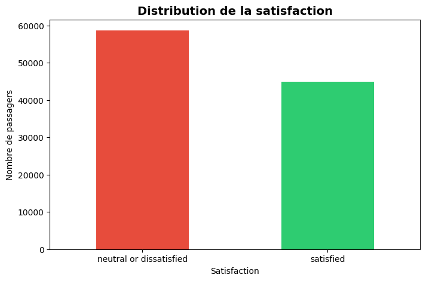

```
satisfaction
neutral or dissatisfied    56.660617
satisfied                  43.339383
Name: proportion, dtype: float64
```

```python
import matplotlib.pyplot as plt
import seaborn as sns

# 1. Déséquilibre des classes
plt.figure(figsize=(8, 5))
train_df['satisfaction'].value_counts().plot(kind='bar', color=['#e74c3c', '#2ecc71'])
plt.title('Distribution de la satisfaction', fontsize=14, fontweight='bold')
plt.xlabel('Satisfaction')
plt.ylabel('Nombre de passagers')
plt.xticks(rotation=0)
plt.show()

# Proportion en %
print(train_df['satisfaction'].value_counts(normalize=True) * 100)
```

The dataset shows a moderate class imbalance: 56% dissatisfied vs 44% satisfied. This ratio remains manageable for our model.

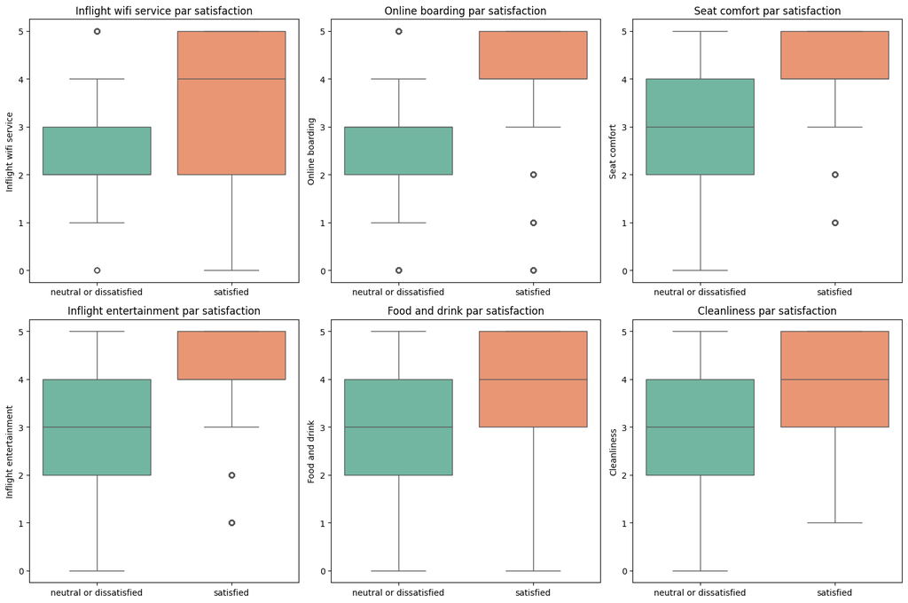

```python
service_features = [
    'Inflight wifi service', 'Online boarding', 'Seat comfort',
    'Inflight entertainment', 'Food and drink', 'Cleanliness'
]

fig, axes = plt.subplots(2, 3, figsize=(15, 10))
axes = axes.flatten()

for i, feature in enumerate(service_features):
    sns.boxplot(data=train_df, x='satisfaction', y=feature, ax=axes[i], palette='Set2')
    axes[i].set_title(f'{feature} par satisfaction')
    axes[i].set_xlabel('')

plt.tight_layout()
plt.show()
```

The boxplots reveal marked differences between satisfied and dissatisfied passengers:

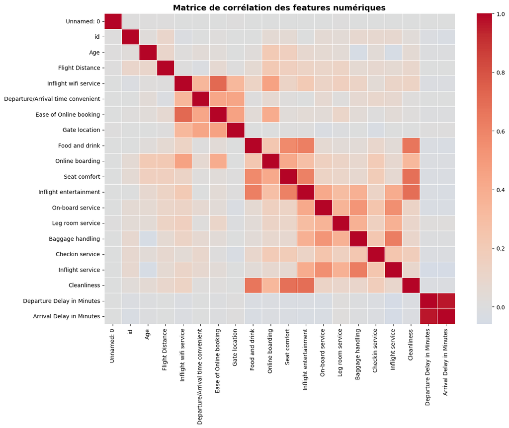

```python
plt.figure(figsize=(14, 10))

numerical_features = train_df.select_dtypes(include=['int64', 'float64']).columns

corr = train_df[numerical_features].corr()
sns.heatmap(corr, annot=False, cmap='coolwarm', center=0, linewidths=0.5)
plt.title('Matrice de corrélation des features numériques', fontsize=14, fontweight='bold')
plt.show()
```

Let's drop departure delay and keep arrival delay.

```python
train_df = train_df.drop(columns=['Departure Delay in Minutes', 'Unnamed: 0', 'id'])
test_df = test_df.drop(columns=['Departure Delay in Minutes', 'Unnamed: 0', 'id'])

print("Cleaned train shape:", train_df.shape)
print("Cleaned test shape:", test_df.shape)
```

```
Cleaned train shape: (103594, 22)
Cleaned test shape: (25893, 22)
```

key insights from the matrix :

- Strong multicollinearity between Departure Delay and Arrival Delay (r ≈ 0.97): one variable should be removed.
- Moderate correlations (0.4-0.6) between service variables (seat comfort, entertainment, food), indicating consistent service quality delivery.
- Age, Flight Distance, and ID variables are largely independent from other features.

No problematic multicollinearity will affect the Random Forest, except for delay variables.

We did not find any duplicates or extreme values problems here, the shape is coherent with what the author's description on kaggle and the data are already splitted into two different data set for training and testing. We only dropped nearly 400 missing values regarding the delay variable, which is quite low considering the size of the datasets. Data are now clean for analysis.

## Preprossessing

We will start by identifying and encoding the target variable satisfaction

```python
train_df["target"] = train_df["satisfaction"].map(
    {"satisfied": 1, "neutral or dissatisfied": 0}
)

test_df["target"] = test_df["satisfaction"].map(
    {"satisfied": 1, "neutral or dissatisfied": 0}
)
```

Then we clearly identify training and testing datas, and we seperate X and Y (independant vs target variable(s)) on both training and testing datas.

```python
X_train = train_df.drop(columns=["satisfaction", "target"])
y_train = train_df["target"]

X_test = test_df.drop(columns=["satisfaction", "target"])
y_test = test_df["target"]
```

Let's take a look/check at the categorial and numerical variables

```python
categorical_features = X_train.select_dtypes(include=["object"]).columns
numerical_features = X_train.select_dtypes(include=["int64", "float64"]).columns
print(categorical_features)
print(numerical_features)
```

```
Index(['Gender', 'Customer Type', 'Type of Travel', 'Class'], dtype='object')
Index(['Age', 'Flight Distance', 'Inflight wifi service',
       'Departure/Arrival time convenient', 'Ease of Online booking',
       'Gate location', 'Food and drink', 'Online boarding', 'Seat comfort',
       'Inflight entertainment', 'On-board service', 'Leg room service',
       'Baggage handling', 'Checkin service', 'Inflight service',
       'Cleanliness', 'Arrival Delay in Minutes'],
      dtype='object')
```

Here variables are first identified based on their data types. Categorical features are encoded using one hot, while numerical features are passed through unchanged. This ensures that all input variables are represented in a numerical format compatible with our ML model.

```python
from sklearn.preprocessing import OneHotEncoder
from sklearn.compose import ColumnTransformer

categorical_features = X_train.select_dtypes(include="object").columns
numerical_features = X_train.select_dtypes(exclude="object").columns

preprocessor = ColumnTransformer(
    transformers=[
        ("cat", OneHotEncoder(handle_unknown="ignore"), categorical_features),
        ("num", "passthrough", numerical_features)
    ]
)
```

Then we apply the preprocessor to the training and test data

```python
# Apply preprocessing
X_train_processed = preprocessor.fit_transform(X_train)
X_test_processed = preprocessor.transform(X_test)
```

Let's check the datas

```python
print(X_train_processed.shape)
print(X_test_processed.shape)
```

```
(103594, 26)
(25893, 26)
```

```python
feature_names = preprocessor.get_feature_names_out()
feature_names
```

```
array(['cat__Gender_Female', 'cat__Gender_Male',
       'cat__Customer Type_Loyal Customer',
       'cat__Customer Type_disloyal Customer',
       'cat__Type of Travel_Business travel',
       'cat__Type of Travel_Personal Travel', 'cat__Class_Business',
       'cat__Class_Eco', 'cat__Class_Eco Plus', 'num__Age',
       'num__Flight Distance', 'num__Inflight wifi service',
       'num__Departure/Arrival time convenient',
       'num__Ease of Online booking', 'num__Gate location',
       'num__Food and drink', 'num__Online boarding', 'num__Seat comfort',
       'num__Inflight entertainment', 'num__On-board service',
       'num__Leg room service', 'num__Baggage handling',
       'num__Checkin service', 'num__Inflight service',
       'num__Cleanliness', 'num__Arrival Delay in Minutes'], dtype=object)
```

Now the preprocessing part is done. Our datas are correctly encoded, we can move onto the random forest part.

## Random Forest as a first model

The random forest model is trained using hyperparameters that balance model flexibility, robustness, and computational cost.

As we saw during the courses, if a sufficiently large number of trees is used to reduce variance and stabilize predictions, the maximum tree depth is controlled to limit overfitting by preventing individual trees from becoming overly complex.

The max_features parameter is set to its standard value for classification to increase diversity among trees.

These choices follow common best practices discussed in the course and were confirmed through consultation with a generative AI assistant (chatgpt), to choose a particular depth here.

Hyperparameters can be later refined.

```python
from sklearn.ensemble import RandomForestClassifier

rf = RandomForestClassifier(
    n_estimators=100,
    max_depth=8,
    random_state=42,
    n_jobs=-1
)

rf.fit(X_train_processed, y_train)
```

```
RandomForestClassifier(max_depth=8, n_jobs=-1, random_state=42)
```

Model is now trained, let's check its performances. After testing n_estimators = 300, without any max_depth, the training AUC was 1 and the testing was 99.8. Since the training was obvisuly overfitted, i decided to limit the max_depth at 8 with only 100 estimators. The respective testing/training AUC are still extremely high, but also extremely close. Therefore, i decided to stick to that model.

# Model's performance test

```python
from sklearn.metrics import roc_auc_score

# Train performance
y_train_proba = rf.predict_proba(X_train_processed)[:, 1]
train_auc = roc_auc_score(y_train, y_train_proba)

# Test performance
y_test_proba = rf.predict_proba(X_test_processed)[:, 1]
test_auc = roc_auc_score(y_test, y_test_proba)

print("Train AUC:", train_auc)
print("Test AUC:", test_auc)
```

```
Train AUC: 0.9875235708115693
Test AUC: 0.9868507811001006
```

```python
from sklearn.model_selection import cross_val_score
scores = cross_val_score(rf, X_train_processed, y_train, cv=5, scoring='roc_auc')
print(f"CV AUC: {scores.mean():.4f} (+/- {scores.std():.4f})")
```

```
CV AUC: 0.9869 (+/- 0.0005)
```

Cross-validation confirms the model's exceptional robustness with an AUC of 98.7% and minimal standard deviation of -/+ 0.0005. The consistency between CV AUC (0.9869), Test AUC (0.9868), and Train AUC (0.9875) demonstrates no overfitting and excellent generalization capability. These results how that our hyperparameter are pretty great choices.

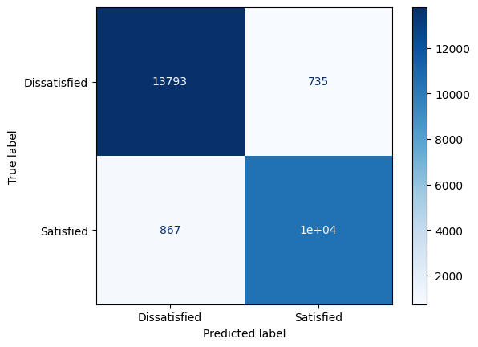

```python
from sklearn.metrics import confusion_matrix, ConfusionMatrixDisplay
import matplotlib.pyplot as plt

# Predictions on test set
y_test_pred = rf.predict(X_test_processed)

# Confusion matrix
cm = confusion_matrix(y_test, y_test_pred)

# Display
disp = ConfusionMatrixDisplay(
    confusion_matrix=cm,
    display_labels=["Dissatisfied", "Satisfied"]
)

disp.plot(cmap="Blues")
plt.show()
```

The confusion matrix shows that most passengers are correctly classified, with only a limited number of misclassifications. Errors are relatively balanced across both classes, confirming the strong and stable performance observed in the AUC results.

Now that we have a quite robust model, let's dive into it to understand how the different variabels influence the accuracy of it.

## Logistic regression as a second model and comparison of the results

```python
from sklearn.linear_model import LogisticRegression
from sklearn.metrics import accuracy_score, roc_curve

# Train Logistic Regression with more iterations and scaled data
lr = LogisticRegression(max_iter=5000, random_state=42, solver='lbfgs')
lr.fit(X_train_processed, y_train)

# Dictionary of models
models = {
    'Random Forest': rf,
    'Logistic Regression': lr
}

# Compare performance
results = []
for name, model in models.items():
    y_pred = model.predict(X_test_processed)
    y_proba = model.predict_proba(X_test_processed)[:, 1]

    results.append({
        'Model': name,
        'Test AUC': roc_auc_score(y_test, y_proba),
        'Accuracy': accuracy_score(y_test, y_pred)
    })

# Display results as DataFrame
results_df = pd.DataFrame(results)
print(results_df)
```

```
                 Model  Test AUC  Accuracy
0        Random Forest  0.986851  0.938130
1  Logistic Regression  0.925513  0.871355
```

Logistic regression underperforms in capturing the complexity of the data, whereas Random Forest achieves substantially better predictive performance. We therefore keep Random Forest as the final model.

## Permutation feature importance (PFI)

```python
from sklearn.inspection import permutation_importance
import pandas as pd

# Compute permutation importance
perm_importance = permutation_importance(
    rf,
    X_test_processed,
    y_test,
    n_repeats=10,
    random_state=42,
    scoring="roc_auc"
)

# Put results in a DataFrame
importances = pd.DataFrame({
    "feature": preprocessor.get_feature_names_out(),
    "importance_mean": perm_importance.importances_mean,
    "importance_std": perm_importance.importances_std
}).sort_values(by="importance_mean", ascending=False)

importances.head(10)
```

|  | feature | importance_mean | importance_std |
| --- | --- | --- | --- |
| 11 | num__Inflight wifi service | 0.044577 | 0.000784 |
| 16 | num__Online boarding | 0.014614 | 0.000334 |
| 4 | cat__Type of Travel_Business travel | 0.012867 | 0.000225 |
| 5 | cat__Type of Travel_Personal Travel | 0.008370 | 0.000171 |
| 2 | cat__Customer Type_Loyal Customer | 0.003700 | 0.000122 |
| 3 | cat__Customer Type_disloyal Customer | 0.003617 | 0.000114 |
| 13 | num__Ease of Online booking | 0.003555 | 0.000110 |
| 22 | num__Checkin service | 0.003437 | 0.000150 |
| 17 | num__Seat comfort | 0.002851 | 0.000191 |
| 18 | num__Inflight entertainment | 0.002629 | 0.000141 |

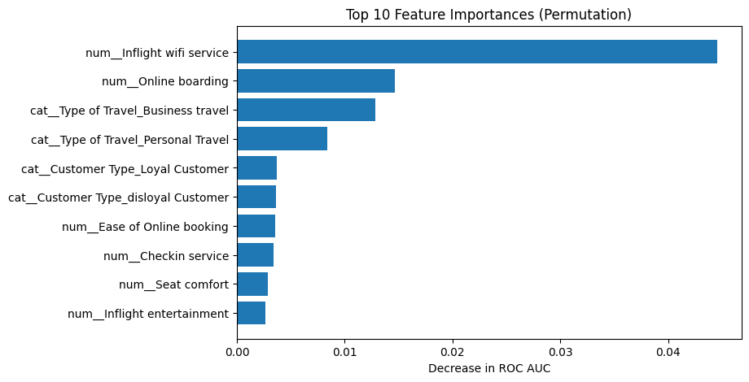

```python
import matplotlib.pyplot as plt

plt.figure(figsize=(8,5))
plt.barh(
    importances["feature"].head(10)[::-1],
    importances["importance_mean"].head(10)[::-1]
)
plt.xlabel("Decrease in ROC AUC")
plt.title("Top 10 Feature Importances (Permutation)")
plt.show()
```

Permutation importance shows that inflight wifi service, by far, the most influential variable in predicting passenger satisfaction. Permuting this feature leads to the largest decrease in ROC AUC. It means that the model relies a lot on this information to distinguish between satisfied and dissatisfied passengers.

The second most important feature is online boarding, this suggests that the experience before and during the flight is a key driver of satisfaction outcomes overall!

Variables such as type of travel and customer type do not directly represent service quality but capture systematic differences in passenger expectations.

Other service-related variables such as ease of online booking, check-in service, and seat comfort show moderate importance, indicating that satisfaction is driven by a combination of multiple service dimensions rather than a single factor.

```python
import pandas as pd

X_test_processed_df = pd.DataFrame(
    X_test_processed,
    columns=feature_names
)
```

Here the previous shape graph didn't have the name of the different features, I ask chatgpt to fix it, that's how I added the code line above.

Now we have the variable's names below.

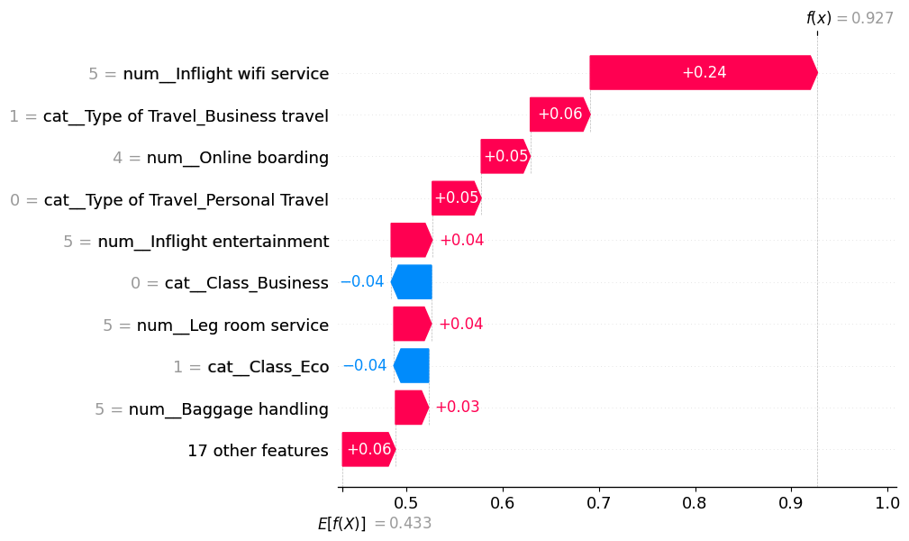

```python
import shap
shap.initjs()

explainer = shap.TreeExplainer(rf)

test_point = 0
X_instance = X_test_processed_df.iloc[[test_point]]

shap_values = explainer(X_instance)

# Waterfall plot for class "Satisfied"
shap.plots.waterfall(shap_values[0, :, 1])
```

However, these effects remain limited compared to the overall impact of service quality.

The SHAP values show that satisfaction is built progressively throughout the entire passenger journey:

- before the flight, digital services such as online boarding and check in already contribute positively.
- during the flight, onboard services play a central role, with inflight WiFi standing out as a major driver of satisfaction in this example.
- after the flight, aspects such as baggage handling and overall service delivery continue to reinforce the positive prediction.

Overall, this example illustrates that passenger satisfaction is not driven by a single element, but by the accumulation of many small service improvements before, during, and after the flight.

```
Chosen index: 2 P(satisfied)= 0.030626873617324097
```

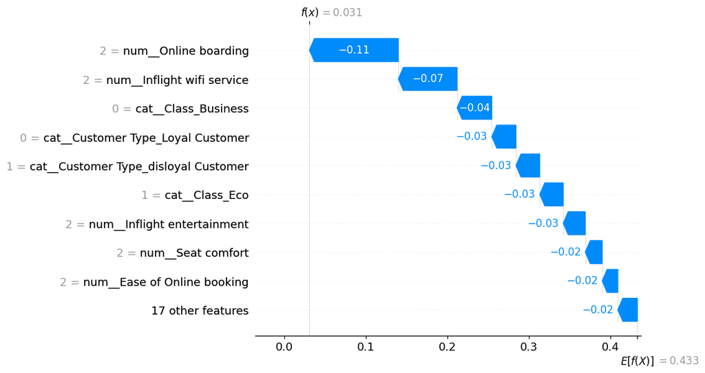

```python
import numpy as np
import shap
shap.initjs()

# 1) Probabilité d'être satisfied (classe 1)
y_test_proba = rf.predict_proba(X_test_processed)[:, 1]
y_test_pred = (y_test_proba >= 0.5).astype(int)  # 1 = satisfied, 0 = dissatisfied

# 2) Prendre un index prédit dissatisfied
idx = np.where(y_test_pred == 0)[0][0]
print("Chosen index:", idx, "P(satisfied)=", y_test_proba[idx])

# 3) SHAP local explanation pour ce passager (classe 1 = satisfied)
X_instance = X_test_processed_df.iloc[[idx]]  # DF avec noms de colonnes
shap_values = explainer(X_instance)

shap.plots.waterfall(shap_values[0, :, 1])
```

This local SHAP explanation shows why the model predicts a very low probability of satisfaction for this passenger. Low ratings across multiple service dimensions consistently decrease the predicted satisfaction, leading to a final probability close to zero. The dissatisfaction is driven by an accumulation of poor experiences rather than by a single dominant factor.

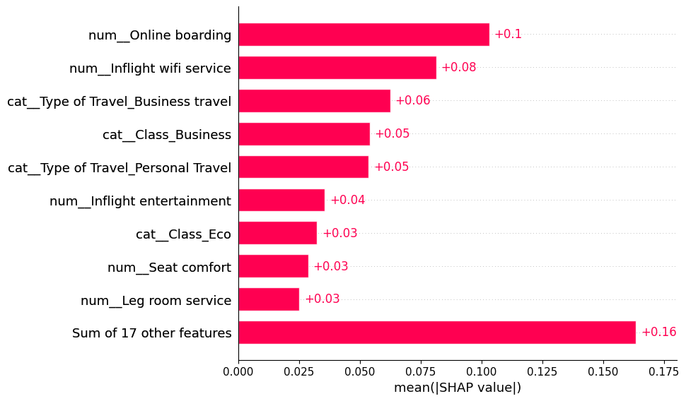

```python
# SHAP explainer (si pas déjà fait)
explainer = shap.TreeExplainer(rf)

# SHAP values sur un sous-échantillon (plus rapide)
X_sample = X_test_processed_df.sample(2000, random_state=42)
shap_values = explainer(X_sample)

# Summary plot (global)
shap.plots.bar(shap_values[:, :, 1])
```

Globally, the results show that passenger satisfaction is driven by the quality of core services provided throughout the travel experience.

Online boarding and inflight WiFi appear as the most influential variables, highlighting the importance of smooth digital interactions and connectivity (or simply avoiding checking at airport, which can induce huge queue and stress for passengers).

Together, these elements contribute to a positive experience before, during, and after the flight, which strongly increases the likelihood of passenger satisfaction.

## Conclusions

Overall, this analysis shows that passenger satisfaction is mainly driven by the quality of services provided throughout the entire travel experience.

The results highlight the strong importance of connectivity related features, especially inflight WiFi, which plays a key role in shaping passengers’ perceptions of the flight. In addition, digital services such as online booking and online boarding significantly contribute to a smoother pre flight experience by reducing waiting times, queues, and stress at the airport.

From a managerial perspective, these findings suggest that airlines could improve passenger satisfaction by investing in better connectivity and higher bandwidth onboard, as well as by further digitalizing the reservation and check in processes.

Overall, enhancing both connectivity and digital touchpoints appears to be an effective strategy to improve the end to end passenger experience and increase overall satisfaction.

## Limits of the model

It would have been interesting to split the dataset to see the key features needed to increase the likelihood to customers to be satisfied regarding their class (business and economics). We can assume that depending on the class, the expectations of passengers can differ.

## Use of AI

I used chatpt to enhance my writing skills, and for some graph codes but all the methodology (otherwise, i specified it), ideas and interpretations are from me. I also asked at the end of each part chatgpt for clues/feedbacks regarding my work. The idea was simply to challenge it and to enhance my creativity.